# Statistical Analysis on Genetic Science

Xiran Wang

xiranwangwork@gmail.com

3/17/2020

This work shows the statistical analysis on solving some genetic problems, such as detecting the Mendelian Inconsistency due to potential genotyping error in every genetic marker for every offspring, performing gene association test using the cleaned genotype data generated from offspring, and identifying genetic markers that are associated with weight-adjusted for father’s id(faid) and sex.

### 1 Setup Dataset

Dataset is avaliable at https://github.com/xiranwang7/Genetic-Analysis.

Data Description:  
faid: Father’s ID (0 indicates founder)  
moid: Mother’s ID (0 indicates founder)  
iid: Individual ID  
sex: M: male, F: Female  
weight: weight  
m11: the first allele in m1 marker  
m12: the second allele in m1 marker

```r
hdata <- read.table(file="hdata.txt", header=T, sep='\t')

# Assume parents' genotypes are correct

kable(hdata) %>%
  kable_styling( ) %>%
  scroll_box(width = "100%", height = "200px")
```

faid

moid

iid

sex

weight

m11

m12

m21

m22

m31

m32

m41

m42

m51

m52

0

0

1

M

334.14

M2

M1

M3

M2

M3

M4

M4

M2

M4

M2

0

0

2

M

364.81

M3

M2

M3

M2

M2

M3

M2

M4

M3

M1

0

0

3

M

383.95

M2

M4

M2

M4

M3

M2

M3

M4

M1

M4

0

0

4

M

349.88

M2

M1

M1

M2

M4

M3

M2

M1

M4

M3

0

0

5

M

357.87

M1

M3

M2

M1

M3

M1

M3

M4

M3

M2

0

0

6

M

364.87

M3

M2

M1

M3

M4

M2

M3

M1

M1

M3

0

0

7

M

361.36

M4

M1

M4

M1

M2

M1

M1

M2

M2

M4

0

0

8

M

357.56

M3

M4

M2

M4

M4

M1

M2

M4

M1

M3

0

0

9

M

333.49

M1

M2

M4

M3

M3

M2

M1

M2

M3

M2

0

0

10

M

360.92

M2

M3

M3

M1

M3

M2

M2

M3

M3

M2

0

0

11

F

1

11

12

F

293.61

M5

M6

M2

M5

M3

M6

M2

M5

M4

M4

1

11

13

M

335.43

M1

M4

M3

M1

M4

M5

M4

M3

M2

M2

1

11

14

M

340.09

M2

M3

M2

M6

M3

M1

M4

M3

M4

M3

1

11

15

M

343.08

M2

M3

M2

M1

M4

M6

M2

M3

M4

M5

1

11

16

F

287.08

M1

M3

M2

M4

M4

M6

M4

M5

M2

M3

1

11

17

F

302.17

M2

M2

M2

M5

M3

M5

M2

M4

M4

M1

1

11

18

M

335.11

M2

M1

M2

M1

M3

M3

M2

M4

M2

M5

1

11

19

M

339.15

M1

M1

M3

M6

M3

M4

M4

M2

M2

M6

1

11

20

M

347.49

M1

M5

M3

M3

M3

M3

M2

M4

M4

M6

1

11

21

F

290.67

M1

M5

M2

M2

M4

M4

M4

M2

M5

M6

1

11

22

M

332.24

M1

M2

M2

M2

M3

M4

M2

M6

M2

M6

1

11

23

F

291.07

M2

M2

M3

M3

M3

M6

M2

M6

M4

M2

1

11

24

F

287.48

M1

M3

M3

M6

M4

M6

M2

M3

M2

M2

1

11

25

M

335.21

M1

M5

M3

M3

M4

M1

M2

M4

M2

M5

1

11

26

F

295.46

M2

M4

M3

M1

M4

M2

M2

M2

M2

M4

1

11

27

M

341.33

M2

M3

M3

M4

M3

M6

M2

M5

M4

M2

1

11

28

F

297.27

M1

M2

M2

M2

M3

M6

M4

M5

M4

M4

1

11

29

M

337.41

M2

M5

M3

M3

M4

M3

M2

M4

M4

M3

1

11

30

F

300.16

M1

M2

M2

M3

M3

M3

M4

M5

M2

M3

1

11

31

M

340.65

M1

M2

M3

M6

M4

M1

M2

M1

M2

M5

1

11

32

F

286.84

M1

M2

M2

M6

M4

M3

M2

M4

M2

M3

1

11

33

F

288.08

M2

M2

M3

M1

M4

M3

M4

M1

M2

M6

1

11

34

M

338.31

M2

M4

M3

M3

M4

M2

M2

M5

M4

M3

1

11

35

M

340.33

M2

M3

M3

M3

M3

M1

M4

M5

M4

M2

1

11

36

F

286.01

M1

M3

M3

M1

M3

M2

M4

M4

M2

M2

1

11

37

M

342.43

M1

M3

M2

M6

M3

M1

M4

M3

M4

M4

1

11

38

F

283.83

M2

M4

M3

M5

M4

M2

M4

M3

M2

M3

1

11

39

M

337.23

M1

M5

M3

M6

M3

M4

M4

M3

M2

M3

1

11

40

F

296.78

M1

M1

M3

M3

M3

M6

M4

M2

M2

M5

1

11

41

M

336.79

M2

M1

M2

M1

M3

M5

M2

M5

M4

M4

1

11

42

M

340.26

M1

M6

M2

M3

M3

M3

M2

M6

M4

M6

1

11

43

F

285.32

M2

M5

M3

M4

M3

M3

M2

M6

M2

M3

1

11

44

F

297.16

M2

M4

M3

M6

M4

M5

M4

M3

M4

M3

1

11

45

M

340.88

M2

M5

M2

M6

M4

M5

M4

M1

M2

M5

1

11

46

F

308.7

M1

M2

M3

M1

M4

M6

M2

M5

M2

M1

1

11

47

F

297.25

M1

M3

M2

M5

M4

M4

M2

M3

M2

M4

1

11

48

F

302.68

M1

M2

M2

M1

M3

M2

M4

M5

M4

M6

1

11

49

M

328.13

M1

M1

M3

M3

M3

M4

M2

M2

M2

M5

1

11

50

M

338.39

M2

M4

M3

M4

M3

M4

M4

M1

M2

M4

2

11

51

M

341.67

M3

M5

M2

M6

M2

M4

M2

M2

M3

M5

2

11

52

F

303.46

M2

M1

M3

M3

M3

M3

M4

M6

M3

M3

2

11

53

M

363.64

M3

M6

M2

M1

M2

M4

M4

M5

M1

M5

2

11

54

M

367.66

M2

M2

M2

M4

M2

M5

M2

M4

M3

M1

2

11

55

M

361.56

M3

M2

M2

M2

M3

M4

M2

M1

M1

M4

2

11

56

M

361.12

M2

M1

M3

M5

M2

M3

M4

M5

M3

M4

2

11

57

M

344.07

M2

M1

M3

M5

M3

M5

M2

M5

M3

M6

2

11

58

M

368.79

M2

M2

M2

M6

M3

M4

M2

M6

M1

M4

2

11

59

M

346.75

M3

M2

M2

M4

M3

M2

M2

M2

M3

M2

2

11

60

F

317.51

M2

M2

M2

M5

M2

M1

M4

M3

M3

M1

2

11

61

F

304

M3

M1

M2

M2

M2

M3

M2

M4

M3

M4

2

11

62

F

309.06

M2

M6

M2

M1

M2

M2

M4

M3

M1

M6

2

11

63

M

368.21

M3

M5

M3

M6

M2

M4

M2

M2

M1

M6

2

11

64

F

307.12

M3

M5

M3

M6

M3

M2

M4

M4

M3

M4

2

11

65

F

315.61

M3

M3

M3

M1

M2

M5

M4

M6

M1

M5

2

11

66

M

360.09

M3

M1

M3

M5

M2

M2

M2

M6

M1

M1

2

11

67

F

323.79

M2

M6

M2

M2

M3

M6

M4

M4

M1

M4

2

11

68

F

297.54

M3

M6

M2

M1

M2

M5

M2

M1

M3

M2

2

11

69

F

317.49

M2

M2

M2

M6

M2

M5

M4

M3

M1

M2

2

11

70

F

317.92

M3

M4

M2

M6

M3

M1

M4

M3

M1

M2

2

11

71

F

304.17

M2

M4

M2

M4

M3

M6

M4

M6

M3

M2

2

11

72

F

309.78

M2

M6

M2

M3

M2

M5

M2

M1

M1

M5

2

11

73

M

350.65

M2

M4

M3

M3

M3

M6

M4

M3

M3

M6

2

11

74

M

353.06

M2

M6

M3

M1

M2

M3

M4

M4

M3

M3

2

11

75

M

346.79

M3

M4

M2

M5

M3

M6

M4

M3

M3

M3

2

11

76

F

310.58

M2

M5

M2

M4

M2

M5

M2

M4

M3

M4

2

11

77

F

325.44

M3

M5

M3

M4

M3

M3

M4

M3

M1

M2

2

11

78

M

362.76

M2

M4

M2

M4

M2

M3

M2

M5

M1

M1

2

11

79

F

319.45

M3

M3

M3

M2

M3

M4

M4

M2

M1

M6

2

11

80

F

311.1

M2

M6

M3

M6

M3

M4

M2

M3

M3

M1

2

11

81

F

321.14

M3

M5

M2

M3

M3

M5

M4

M4

M1

M6

2

11

82

M

360.56

M3

M5

M2

M2

M2

M6

M2

M2

M1

M3

2

11

83

F

315

M3

M1

M3

M2

M3

M2

M2

M3

M1

M5

2

11

84

M

360.9

M2

M4

M2

M4

M3

M5

M2

M3

M1

M2

2

11

85

F

307.06

M2

M4

M2

M3

M2

M4

M2

M2

M3

M5

2

11

86

M

354.28

M3

M1

M2

M6

M2

M5

M2

M3

M3

M3

2

11

87

F

317.35

M3

M3

M2

M5

M3

M1

M4

M4

M1

M6

2

11

88

F

322.19

M3

M4

M3

M6

M3

M3

M2

M4

M1

M1

2

11

89

M

362.05

M3

M4

M2

M2

M2

M5

M2

M5

M1

M6

3

11

90

F

308.83

M2

M1

M4

M4

M2

M5

M3

M2

M4

M3

3

11

91

M

347.01

M4

M2

M4

M1

M2

M5

M3

M1

M4

M5

3

11

92

M

360.21

M4

M6

M2

M6

M3

M3

M3

M3

M1

M1

3

11

93

F

320.95

M2

M5

M4

M4

M2

M4

M4

M5

M4

M4

3

11

94

F

327.27

M2

M3

M4

M1

M3

M2

M4

M3

M1

M5

3

11

95

M

356.88

M4

M4

M4

M3

M3

M3

M3

M6

M4

M2

3

11

96

M

378.7

M2

M1

M2

M2

M3

M2

M4

M4

M1

M5

3

11

97

M

374.14

M2

M1

M4

M6

M2

M1

M4

M2

M1

M4

3

11

98

F

325.31

M2

M2

M2

M5

M3

M6

M3

M2

M1

M6

3

11

99

M

363.51

M2

M4

M2

M4

M3

M4

M3

M4

M4

M5

3

11

100

M

359.92

M4

M4

M4

M6

M2

M5

M4

M2

M1

M3

3

11

101

M

369.05

M4

M6

M2

M4

M3

M1

M3

M3

M1

M6

3

11

102

F

312.25

M4

M2

M4

M4

M2

M4

M4

M3

M4

M5

3

11

103

F

323.73

M4

M2

M4

M1

M2

M3

M3

M6

M1

M2

3

11

104

F

329.21

M4

M3

M4

M3

M3

M4

M3

M1

M1

M3

3

11

105

M

358.48

M2

M4

M4

M1

M2

M5

M4

M2

M4

M3

3

11

106

M

376.73

M4

M3

M4

M4

M2

M4

M4

M1

M1

M2

3

11

107

F

317.26

M2

M2

M2

M1

M3

M4

M4

M3

M1

M4

3

11

108

F

324.79

M4

M3

M2

M6

M3

M4

M3

M2

M4

M1

3

11

109

M

357.87

M2

M3

M2

M6

M3

M1

M3

M6

M4

M5

3

11

110

M

386.28

M4

M1

M4

M4

M2

M6

M3

M1

M4

M1

3

11

111

F

324.8

M2

M5

M4

M4

M2

M4

M3

M3

M1

M5

3

11

112

M

369.88

M4

M1

M2

M6

M3

M4

M3

M2

M1

M5

3

11

113

F

303.99

M2

M4

M2

M3

M3

M6

M4

M3

M4

M5

3

11

114

M

365.34

M4

M1

M2

M2

M2

M1

M4

M5

M4

M5

3

11

115

M

356.46

M2

M6

M2

M2

M2

M6

M3

M5

M4

M6

3

11

116

M

375.09

M4

M4

M2

M5

M2

M6

M3

M1

M1

M3

3

11

117

F

334.19

M4

M6

M2

M5

M3

M6

M4

M4

M4

M1

3

11

118

M

380.77

M2

M6

M2

M5

M2

M3

M3

M5

M1

M6

3

11

119

M

367.54

M2

M3

M2

M5

M2

M1

M4

M2

M1

M1

3

11

120

F

324.66

M2

M4

M2

M6

M2

M3

M4

M4

M4

M4

3

11

121

M

368.46

M2

M5

M4

M6

M3

M3

M3

M1

M4

M1

3

11

122

M

370.57

M4

M3

M4

M3

M2

M3

M3

M4

M1

M2

3

11

123

F

312.06

M2

M6

M4

M6

M2

M5

M4

M2

M4

M4

3

11

124

F

327.78

M2

M5

M2

M5

M2

M5

M3

M3

M1

M4

3

11

125

M

356.18

M4

M4

M4

M2

M2

M2

M4

M6

M4

M3

3

11

126

M

366.18

M2

M4

M4

M4

M3

M2

M3

M6

M1

M5

3

11

127

F

325.58

M2

M3

M4

M4

M3

M2

M4

M6

M1

M4

3

11

128

F

313.66

M2

M3

M2

M6

M3

M3

M4

M4

M4

M2

4

11

129

M

336.61

M1

M1

M1

M3

M4

M1

M2

M3

M4

M2

4

11

130

M

366.02

M2

M1

M2

M3

M3

M4

M1

M6

M4

M1

4

11

131

M

343.11

M1

M3

M2

M6

M4

M1

M2

M6

M3

M4

4

11

132

M

343.05

M1

M6

M1

M1

M4

M1

M1

M4

M3

M6

4

11

133

M

342.62

M2

M4

M2

M2

M4

M2

M2

M1

M4

M3

4

11

134

F

318.95

M2

M2

M1

M4

M4

M6

M1

M6

M3

M1

4

11

135

F

292.95

M1

M6

M2

M2

M3

M4

M2

M5

M4

M3

4

11

136

F

299.05

M2

M4

M1

M3

M4

M1

M1

M1

M3

M5

4

11

137

F

299.28

M1

M5

M1

M3

M4

M1

M2

M6

M3

M2

4

11

138

F

296.51

M1

M5

M2

M3

M4

M6

M1

M4

M4

M3

4

11

139

M

341.64

M1

M5

M2

M5

M3

M5

M2

M2

M3

M2

4

11

140

M

356.74

M2

M2

M2

M4

M3

M1

M2

M1

M4

M1

4

11

141

F

294.03

M1

M1

M2

M3

M3

M1

M1

M4

M3

M5

4

11

142

F

313.02

M2

M6

M1

M2

M3

M5

M1

M5

M3

M1

4

11

143

M

354.29

M2

M4

M2

M4

M4

M5

M1

M6

M3

M6

4

11

144

F

306.87

M2

M4

M1

M1

M4

M2

M1

M5

M3

M6

4

11

145

M

344.31

M1

M1

M1

M5

M4

M6

M1

M2

M3

M2

4

11

146

F

290.63

M1

M5

M1

M5

M4

M3

M1

M5

M3

M3

4

11

147

M

349.88

M1

M6

M1

M4

M3

M6

M2

M2

M4

M4

4

11

148

M

340.79

M2

M4

M2

M3

M4

M2

M1

M5

M4

M3

4

11

149

M

347.12

M2

M3

M1

M5

M4

M1

M2

M6

M4

M2

4

11

150

F

305.4

M1

M5

M2

M4

M3

M2

M1

M2

M4

M4

4

11

151

F

297.34

M1

M6

M2

M2

M4

M6

M1

M5

M4

M6

4

11

152

F

304.06

M2

M3

M2

M5

M3

M2

M2

M1

M4

M5

4

11

153

M

348.18

M1

M5

M2

M3

M4

M6

M2

M3

M4

M2

4

11

154

M

352.5

M2

M5

M1

M1

M4

M1

M2

M4

M4

M5

4

11

155

F

305.29

M1

M2

M1

M1

M4

M5

M1

M3

M4

M2

4

11

156

M

339.77

M2

M1

M2

M6

M4

M3

M1

M3

M3

M3

4

11

157

F

297.18

M1

M5

M2

M3

M4

M3

M1

M1

M4

M3

4

11

158

F

300.57

M2

M4

M1

M6

M4

M4

M1

M5

M4

M4

4

11

159

F

311.63

M2

M1

M2

M6

M4

M5

M1

M1

M4

M1

4

11

160

M

349.91

M1

M1

M2

M6

M3

M1

M2

M1

M3

M5

4

11

161

F

309.69

M2

M1

M1

M1

M4

M2

M1

M6

M4

M1

4

11

162

M

335.01

M1

M2

M1

M1

M4

M1

M1

M3

M4

M2

4

11

163

F

301.94

M2

M4

M1

M3

M3

M6

M2

M2

M4

M4

4

11

164

F

304.57

M2

M1

M1

M2

M4

M1

M1

M4

M4

M6

4

11

165

M

347.69

M2

M6

M1

M6

M4

M3

M1

M3

M3

M5

4

11

166

F

296.38

M2

M6

M1

M6

M4

M6

M2

M4

M4

M2

4

11

167

F

309.35

M1

M1

M1

M6

M4

M3

M2

M5

M4

M5

4

11

168

M

345.36

M2

M2

M1

M2

M3

M4

M1

M3

M3

M5

5

11

169

M

346.73

M1

M4

M2

M6

M1

M6

M4

M6

M3

M4

5

11

170

F

318.54

M1

M4

M2

M4

M3

M5

M4

M4

M3

M1

5

11

171

F

302.11

M3

M3

M1

M6

M1

M5

M4

M5

M3

M4

5

11

172

M

353.33

M3

M5

M2

M3

M1

M2

M3

M5

M3

M3

5

11

173

M

340.83

M3

M1

M1

M5

M3

M1

M3

M4

M3

M6

5

11

174

F

300.54

M1

M4

M1

M1

M3

M3

M4

M1

M2

M4

5

11

175

F

308.68

M1

M5

M2

M2

M3

M4

M4

M2

M2

M5

5

11

176

M

373.18

M3

M2

M1

M6

M1

M4

M3

M5

M3

M1

5

11

177

F

299.28

M3

M1

M1

M6

M3

M4

M4

M4

M2

M4

5

11

178

M

366.41

M3

M3

M2

M3

M1

M2

M4

M3

M3

M1

5

11

179

M

352.75

M1

M5

M2

M4

M3

M6

M4

M3

M2

M4

5

11

180

F

307.34

M1

M2

M2

M2

M1

M2

M4

M5

M2

M5

5

11

181

F

302.24

M3

M3

M2

M6

M3

M2

M4

M4

M3

M4

5

11

182

F

298.47

M1

M5

M1

M5

M3

M2

M3

M1

M2

M3

5

11

183

F

306.9

M1

M5

M1

M6

M1

M4

M3

M6

M3

M5

5

11

184

M

354.11

M1

M2

M2

M5

M1

M4

M3

M3

M3

M2

5

11

185

F

307.21

M1

M3

M2

M5

M3

M1

M4

M3

M2

M4

5

11

186

F

307.48

M1

M4

M1

M3

M1

M3

M4

M2

M2

M3

5

11

187

F

307.79

M1

M3

M1

M1

M1

M6

M4

M3

M3

M2

5

11

188

M

349.51

M3

M1

M1

M2

M1

M5

M4

M1

M2

M4

5

11

189

F

304.03

M1

M1

M1

M2

M1

M3

M4

M1

M3

M2

5

11

190

M

348.94

M3

M5

M2

M2

M3

M3

M3

M6

M2

M2

5

11

191

F

313.66

M1

M6

M2

M2

M1

M5

M3

M5

M2

M4

5

11

192

M

355.5

M3

M4

M2

M6

M3

M3

M4

M1

M3

M2

5

11

193

F

309.87

M3

M4

M2

M4

M1

M1

M4

M5

M2

M3

5

11

194

F

307.09

M1

M3

M2

M1

M3

M3

M3

M5

M3

M3

5

11

195

M

344.39

M3

M6

M2

M3

M3

M3

M3

M2

M2

M6

5

11

196

M

356.58

M1

M4

M2

M4

M3

M1

M4

M1

M3

M6

5

11

197

M

366.9

M3

M4

M2

M3

M1

M5

M4

M3

M2

M1

5

11

198

F

304.79

M1

M6

M2

M3

M3

M5

M3

M3

M2

M4

5

11

199

F

319.91

M1

M5

M1

M3

M1

M6

M3

M2

M3

M1

5

11

200

M

344.85

M1

M6

M2

M1

M3

M6

M3

M5

M3

M2

5

11

201

M

372.65

M3

M6

M2

M6

M1

M6

M3

M2

M3

M1

5

11

202

F

309.71

M3

M1

M1

M1

M3

M6

M3

M4

M2

M6

5

11

203

M

353.31

M3

M3

M2

M2

M1

M1

M3

M1

M2

M2

5

11

204

F

298.37

M3

M6

M2

M3

M1

M5

M4

M4

M2

M5

5

11

205

M

347.81

M3

M1

M1

M2

M3

M5

M4

M3

M3

M2

5

11

206

M

351.86

M3

M4

M2

M3

M1

M3

M3

M6

M3

M5

5

11

207

M

346.21

M3

M1

M2

M5

M1

M6

M4

M2

M3

M5

5

11

208

M

372.25

M1

M4

M2

M4

M3

M5

M4

M4

M3

M1

6

11

209

F

304.1

M3

M6

M1

M5

M4

M2

M3

M2

M3

M4

6

11

210

M

352.22

M2

M1

M3

M5

M4

M3

M1

M2

M3

M4

6

11

211

F

298.73

M2

M3

M3

M1

M4

M4

M1

M4

M3

M6

6

11

212

F

320.97

M3

M1

M1

M3

M2

M3

M3

M3

M1

M2

6

11

213

M

352.78

M2

M2

M1

M2

M4

M1

M3

M2

M3

M5

6

11

214

M

364.84

M3

M6

M1

M2

M4

M4

M1

M1

M1

M4

6

11

215

F

318.46

M2

M1

M3

M1

M4

M4

M1

M4

M1

M6

6

11

216

M

363.94

M3

M2

M3

M2

M4

M6

M3

M4

M1

M6

6

11

217

F

311.79

M3

M4

M1

M1

M2

M5

M3

M1

M3

M1

6

11

218

F

299.86

M2

M2

M3

M3

M4

M2

M3

M2

M3

M5

6

11

219

M

365.4

M2

M2

M1

M3

M2

M3

M1

M2

M1

M5

6

11

220

F

304.95

M2

M4

M3

M1

M2

M1

M3

M5

M3

M6

6

11

221

F

323.74

M2

M4

M3

M4

M4

M6

M3

M3

M1

M4

6

11

222

F

304.06

M2

M1

M1

M5

M2

M2

M3

M3

M3

M2

6

11

223

F

314.7

M3

M3

M3

M6

M2

M1

M1

M6

M1

M6

6

11

224

F

315.32

M3

M4

M1

M4

M2

M2

M3

M3

M1

M6

6

11

225

F

303.59

M3

M6

M1

M1

M4

M2

M3

M5

M3

M4

6

11

226

F

299.42

M3

M3

M3

M1

M2

M3

M3

M6

M3

M3

6

11

227

M

346.12

M3

M3

M1

M6

M4

M2

M3

M3

M3

M5

6

11

228

M

367.21

M3

M5

M3

M5

M4

M3

M3

M3

M1

M1

6

11

229

F

319.89

M2

M6

M1

M3

M4

M1

M3

M5

M1

M1

6

11

230

F

296.57

M3

M3

M3

M3

M4

M6

M3

M4

M3

M2

6

11

231

F

321.95

M3

M4

M1

M6

M2

M3

M3

M4

M1

M4

6

11

232

M

350.66

M3

M2

M1

M4

M2

M2

M1

M6

M3

M5

6

11

233

M

372.15

M2

M6

M1

M6

M4

M5

M1

M4

M1

M3

6

11

234

M

362.07

M3

M3

M3

M6

M2

M2

M3

M1

M1

M4

6

11

235

M

335.96

M3

M2

M1

M5

M4

M2

M1

M2

M3

M6

6

11

236

F

317.47

M2

M5

M1

M6

M2

M5

M3

M4

M1

M2

6

11

237

F

300.71

M2

M3

M3

M4

M4

M3

M1

M2

M3

M3

6

11

238

F

315.2

M3

M6

M3

M4

M2

M1

M3

M5

M3

M1

6

11

239

F

315.47

M3

M5

M3

M3

M4

M2

M3

M4

M1

M3

6

11

240

M

354.62

M3

M3

M1

M6

M4

M1

M3

M5

M3

M5

6

11

241

F

287.17

M2

M5

M1

M2

M2

M3

M3

M3

M3

M6

6

11

242

M

374.74

M3

M1

M1

M2

M2

M4

M1

M3

M1

M6

6

11

243

M

345.36

M2

M3

M3

M1

M4

M4

M1

M3

M3

M2

6

11

244

M

361.28

M2

M6

M3

M1

M4

M4

M1

M3

M3

M1

6

11

245

M

343.51

M2

M2

M1

M3

M4

M5

M1

M3

M3

M2

6

11

246

F

304.72

M2

M2

M3

M2

M2

M1

M1

M2

M3

M5

6

11

247

M

350.86

M2

M6

M3

M2

M4

M2

M3

M3

M3

M5

6

11

248

F

295.54

M3

M2

M3

M5

M4

M3

M3

M2

M3

M6

7

11

249

M

352.22

M4

M3

M4

M1

M1

M5

M1

M6

M4

M4

7

11

250

M

358.96

M4

M5

M1

M1

M1

M3

M2

M1

M4

M6

7

11

251

F

307.35

M4

M4

M1

M3

M2

M4

M2

M1

M2

M6

7

11

252

F

302.28

M4

M6

M4

M1

M2

M1

M2

M1

M4

M4

7

11

253

F

309.1

M1

M5

M1

M2

M2

M5

M2

M5

M4

M4

7

11

254

M

354.33

M4

M1

M4

M4

M1

M1

M2

M2

M4

M5

7

11

255

M

355.25

M4

M2

M4

M5

M1

M3

M2

M3

M2

M2

7

11

256

F

317.16

M4

M5

M1

M2

M1

M3

M1

M5

M4

M1

7

11

257

M

374.44

M1

M3

M4

M2

M2

M6

M1

M4

M4

M1

7

11

258

M

367.69

M4

M5

M4

M6

M1

M1

M1

M2

M2

M1

7

11

259

F

305.44

M4

M2

M1

M6

M2

M3

M2

M6

M4

M5

7

11

260

M

353.79

M1

M5

M1

M3

M1

M5

M1

M4

M4

M5

7

11

261

F

305.61

M4

M2

M1

M5

M2

M5

M1

M5

M2

M3

7

11

262

M

346.08

M1

M3

M1

M3

M2

M2

M1

M3

M4

M6

7

11

263

M

372.78

M1

M2

M1

M1

M2

M4

M1

M1

M4

M1

7

11

264

M

339.39

M4

M5

M4

M1

M2

M5

M2

M3

M4

M5

7

11

265

F

306.33

M4

M2

M1

M6

M2

M2

M2

M5

M4

M3

7

11

266

M

352.03

M1

M3

M1

M1

M1

M4

M1

M6

M4

M3

7

11

267

F

311.75

M1

M5

M1

M5

M2

M1

M2

M5

M4

M4

7

11

268

F

303.86

M1

M2

M4

M1

M1

M3

M2

M5

M2

M3

7

11

269

M

346.07

M4

M3

M4

M3

M1

M5

M1

M4

M2

M6

7

11

270

M

350.98

M1

M3

M4

M4

M1

M3

M1

M4

M4

M3

7

11

271

M

349.82

M1

M2

M4

M5

M2

M6

M1

M2

M4

M4

7

11

272

M

355.14

M4

M5

M1

M1

M2

M4

M1

M1

M4

M3

7

11

273

F

308.33

M4

M2

M1

M6

M1

M6

M2

M1

M2

M6

7

11

274

M

350.03

M1

M2

M4

M2

M1

M6

M1

M4

M2

M4

7

11

275

F

290.64

M4

M1

M1

M4

M1

M5

M1

M2

M4

M2

7

11

276

M

351.72

M4

M3

M1

M4

M2

M6

M2

M5

M2

M6

7

11

277

M

350.15

M1

M5

M1

M4

M2

M1

M2

M3

M2

M2

7

11

278

F

313.07

M1

M4

M4

M5

M1

M3

M1

M2

M4

M4

7

11

279

M

348.47

M4

M6

M4

M4

M2

M1

M2

M6

M4

M5

7

11

280

M

353.11

M4

M5

M4

M2

M2

M3

M1

M2

M4

M2

7

11

281

M

366.05

M1

M4

M4

M3

M2

M5

M2

M3

M4

M1

7

11

282

F

300.92

M4

M5

M1

M6

M1

M4

M1

M3

M2

M6

7

11

283

M

352.94

M1

M5

M1

M5

M2

M3

M1

M4

M2

M5

7

11

284

M

350.54

M1

M5

M4

M4

M1

M5

M2

M6

M4

M5

7

11

285

F

305.92

M4

M5

M4

M5

M1

M5

M1

M3

M2

M3

7

11

286

F

317.18

M4

M1

M1

M2

M1

M4

M2

M4

M4

M3

7

11

287

F

304.06

M4

M1

M1

M3

M2

M1

M2

M5

M4

M5

7

11

288

M

353.33

M4

M5

M4

M6

M1

M1

M2

M3

M4

M3

8

11

289

M

342.43

M3

M3

M2

M5

M4

M6

M4

M2

M3

M6

8

11

290

F

295.62

M4

M6

M2

M2

M4

M1

M2

M1

M3

M3

8

11

291

F

310.39

M3

M5

M4

M2

M4

M2

M4

M6

M1

M2

8

11

292

M

356.85

M4

M2

M2

M1

M4

M3

M4

M3

M1

M6

8

11

293

F

312.21

M4

M5

M2

M6

M1

M1

M4

M6

M1

M1

8

11

294

F

313.14

M3

M5

M2

M1

M1

M5

M4

M4

M1

M3

8

11

295

M

359.6

M3

M3

M4

M2

M4

M3

M2

M3

M1

M2

8

11

296

M

352.32

M4

M4

M4

M6

M4

M3

M2

M1

M3

M6

8

11

297

M

347.55

M3

M5

M2

M2

M1

M6

M4

M1

M3

M6

8

11

298

M

366.35

M3

M5

M2

M2

M4

M5

M4

M1

M1

M4

8

11

299

F

289.02

M3

M3

M2

M4

M4

M1

M4

M6

M3

M4

8

11

300

F

301.35

M3

M2

M2

M4

M1

M5

M4

M6

M3

M3

8

11

301

M

336.32

M4

M1

M2

M4

M1

M3

M2

M3

M3

M4

8

11

302

M

345.17

M3

M3

M4

M2

M1

M6

M2

M1

M3

M3

8

11

303

F

317.38

M3

M6

M2

M4

M1

M2

M4

M4

M1

M5

8

11

304

M

353.85

M3

M5

M2

M6

M1

M3

M4

M6

M1

M1

8

11

305

M

337.38

M4

M6

M2

M1

M4

M3

M2

M4

M3

M4

8

11

306

F

305.88

M4

M4

M4

M6

M1

M1

M2

M3

M1

M3

8

11

307

F

324.37

M4

M2

M2

M5

M4

M3

M2

M6

M1

M3

8

11

308

F

313.61

M4

M3

M4

M3

M4

M3

M2

M5

M1

M2

8

11

309

F

305.34

M3

M4

M4

M2

M1

M6

M2

M2

M1

M2

8

11

310

M

363.57

M4

M1

M4

M4

M4

M2

M4

M4

M1

M5

8

11

311

M

365.02

M3

M3

M4

M2

M4

M4

M2

M5

M1

M5

8

11

312

F

299.25

M3

M1

M4

M1

M4

M2

M2

M5

M3

M6

8

11

313

F

307.21

M4

M1

M2

M1

M1

M3

M4

M6

M1

M1

8

11

314

M

337.78

M3

M6

M2

M4

M4

M5

M4

M3

M3

M6

8

11

315

F

301.3

M3

M4

M2

M6

M1

M3

M2

M3

M3

M5

8

11

316

M

352.09

M3

M2

M4

M3

M4

M4

M2

M4

M3

M6

8

11

317

F

319.46

M3

M1

M2

M2

M4

M1

M4

M4

M3

M1

8

11

318

F

294.93

M4

M6

M2

M5

M4

M4

M4

M5

M3

M3

8

11

319

F

309.53

M3

M4

M4

M4

M4

M2

M4

M2

M1

M3

8

11

320

F

317.05

M3

M5

M4

M3

M4

M6

M2

M4

M1

M1

8

11

321

F

311.89

M4

M6

M2

M4

M4

M5

M2

M5

M1

M1

8

11

322

F

313.62

M4

M1

M2

M3

M4

M4

M2

M5

M1

M6

8

11

323

M

359.94

M4

M5

M4

M1

M4

M2

M4

M5

M1

M6

8

11

324

F

310.34

M3

M2

M4

M6

M1

M1

M2

M1

M1

M5

8

11

325

F

312.85

M4

M6

M4

M4

M4

M5

M2

M3

M1

M6

8

11

326

F

307.01

M4

M5

M2

M4

M4

M4

M4

M4

M1

M2

8

11

327

F

317.54

M3

M5

M4

M4

M1

M3

M2

M2

M1

M5

8

11

328

F

311.64

M4

M6

M2

M3

M4

M2

M2

M6

M1

M1

9

11

329

F

285.68

M2

M2

M4

M4

M3

M5

M1

M4

M2

M3

9

11

330

M

339.96

M2

M1

M4

M4

M2

M3

M2

M1

M2

M2

9

11

331

M

336.75

M1

M6

M4

M3

M2

M6

M2

M4

M3

M2

9

11

332

M

363.64

M1

M1

M4

M6

M3

M6

M2

M1

M3

M1

9

11

333

M

342.07

M1

M6

M4

M3

M3

M5

M1

M1

M3

M3

9

11

334

F

314.09

M1

M6

M4

M3

M3

M6

M1

M6

M3

M1

9

11

335

F

292.69

M2

M6

M4

M3

M2

M2

M1

M2

M2

M5

9

11

336

M

340.98

M1

M5

M4

M6

M3

M3

M1

M1

M2

M3

9

11

337

F

289.68

M1

M6

M3

M2

M2

M2

M2

M4

M3

M6

9

11

338

M

338.67

M2

M3

M4

M5

M2

M3

M1

M4

M2

M6

9

11

339

M

335.37

M2

M1

M4

M6

M2

M2

M2

M3

M3

M4

9

11

340

F

291.48

M2

M3

M3

M3

M2

M1

M2

M1

M3

M5

9

11

341

F

288.94

M2

M3

M4

M2

M2

M1

M1

M2

M3

M3

9

11

342

M

335.26

M1

M4

M3

M1

M3

M2

M2

M6

M2

M4

9

11

343

M

337.08

M2

M3

M3

M5

M2

M4

M1

M1

M2

M3

9

11

344

F

296.76

M2

M2

M4

M2

M3

M2

M2

M2

M3

M4

9

11

345

M

339.57

M1

M1

M4

M1

M3

M2

M1

M5

M3

M6

9

11

346

F

300.24

M2

M5

M4

M5

M3

M1

M2

M4

M3

M5

9

11

347

M

333.91

M1

M6

M4

M6

M3

M6

M2

M3

M2

M2

9

11

348

F

292.53

M1

M5

M3

M5

M2

M3

M2

M6

M2

M2

9

11

349

F

306.51

M1

M1

M3

M2

M3

M5

M2

M4

M3

M1

9

11

350

M

330.95

M2

M2

M4

M1

M3

M6

M1

M2

M3

M2

9

11

351

M

342.93

M2

M5

M4

M2

M3

M4

M2

M1

M2

M5

9

11

352

M

332.48

M1

M5

M3

M2

M2

M5

M2

M5

M2

M2

9

11

353

F

287.47

M1

M3

M3

M6

M3

M1

M1

M5

M3

M4

9

11

354

M

350.52

M1

M5

M4

M5

M3

M3

M1

M5

M2

M1

9

11

355

F

291.41

M1

M4

M3

M1

M3

M4

M1

M3

M2

M5

9

11

356

M

348.68

M2

M3

M4

M2

M3

M2

M2

M2

M3

M4

9

11

357

F

282.83

M2

M5

M4

M3

M3

M4

M1

M2

M2

M6

9

11

358

M

333.26

M2

M1

M4

M3

M3

M2

M1

M4

M2

M4

9

11

359

F

290.33

M1

M1

M4

M3

M3

M5

M2

M4

M2

M4

9

11

360

M

344.07

M1

M3

M4

M6

M2

M4

M1

M5

M2

M4

9

11

361

F

317.12

M1

M2

M3

M6

M2

M1

M2

M6

M3

M1

9

11

362

M

336.55

M2

M5

M3

M3

M2

M1

M1

M1

M2

M2

9

11

363

F

312.88

M1

M3

M3

M6

M2

M1

M1

M4

M3

M1

9

11

364

F

298.56

M2

M5

M3

M3

M2

M2

M2

M4

M3

M4

9

11

365

M

350.27

M1

M6

M3

M5

M3

M6

M2

M1

M3

M1

9

11

366

M

351.19

M1

M1

M3

M3

M3

M2

M2

M6

M2

M1

9

11

367

F

319.34

M2

M1

M3

M3

M2

M2

M1

M5

M2

M1

9

11

368

M

347.67

M2

M4

M3

M1

M3

M5

M2

M1

M3

M4

10

11

369

F

323.57

M2

M1

M1

M1

M2

M6

M2

M4

M3

M1

10

11

370

M

353.69

M2

M6

M3

M1

M3

M5

M3

M6

M2

M5

10

11

371

F

309.62

M2

M4

M1

M6

M3

M6

M2

M2

M3

M2

10

11

372

M

342.93

M3

M5

M3

M2

M2

M4

M3

M2

M2

M5

10

11

373

M

348.21

M2

M3

M3

M4

M2

M4

M2

M6

M3

M4

10

11

374

M

361.41

M3

M2

M3

M4

M2

M1

M2

M5

M3

M1

10

11

375

F

313.62

M2

M1

M1

M2

M3

M2

M2

M5

M2

M5

10

11

376

F

304.11

M2

M4

M3

M5

M3

M3

M2

M5

M2

M3

10

11

377

F

299.07

M2

M2

M1

M3

M2

M1

M3

M4

M3

M6

10

11

378

F

297.79

M2

M1

M1

M4

M2

M1

M2

M1

M2

M6

10

11

379

F

308.97

M2

M2

M3

M1

M3

M1

M2

M2

M3

M5

10

11

380

F

302.01

M3

M4

M1

M2

M2

M5

M3

M2

M2

M2

10

11

381

M

354.21

M2

M2

M1

M4

M3

M1

M3

M6

M2

M4

10

11

382

F

310.76

M2

M4

M1

M5

M3

M1

M3

M6

M3

M3

10

11

383

F

310.15

M2

M3

M3

M5

M3

M5

M3

M1

M2

M5

10

11

384

M

343.71

M2

M2

M3

M2

M2

M4

M3

M4

M2

M6

10

11

385

F

303.21

M3

M1

M3

M3

M2

M1

M3

M1

M2

M5

10

11

386

M

357.66

M3

M6

M1

M3

M3

M2

M2

M2

M2

M3

10

11

387

M

347.9

M3

M5

M1

M1

M3

M2

M3

M2

M3

M3

10

11

388

M

360.19

M3

M1

M1

M6

M2

M6

M3

M2

M3

M6

10

11

389

M

365.78

M2

M6

M1

M3

M2

M6

M2

M6

M2

M3

10

11

390

M

351.1

M3

M2

M1

M1

M2

M4

M3

M2

M3

M2

10

11

391

F

308.74

M2

M2

M1

M2

M2

M5

M2

M4

M3

M2

10

11

392

M

352.73

M3

M1

M1

M3

M3

M2

M3

M3

M3

M2

10

11

393

M

344.64

M3

M1

M3

M5

M3

M5

M2

M5

M3

M4

10

11

394

M

349.25

M2

M1

M3

M3

M3

M1

M2

M1

M3

M4

10

11

395

F

313.84

M3

M3

M3

M6

M3

M5

M3

M3

M3

M6

10

11

396

F

305.76

M2

M1

M3

M1

M2

M6

M2

M4

M2

M4

10

11

397

F

312.57

M3

M4

M1

M5

M3

M2

M2

M5

M3

M2

10

11

398

F

311.7

M3

M3

M1

M5

M2

M4

M3

M6

M2

M4

10

11

399

M

355.51

M2

M2

M3

M6

M3

M6

M3

M3

M2

M5

10

11

400

M

367.26

M3

M6

M3

M3

M3

M2

M3

M2

M2

M1

10

11

401

F

311.7

M2

M2

M1

M3

M2

M4

M2

M1

M2

M5

10

11

402

M

367.78

M2

M6

M3

M2

M3

M2

M3

M2

M3

M1

10

11

403

M

354.55

M3

M2

M3

M1

M2

M2

M2

M4

M3

M2

10

11

404

F

299.74

M2

M2

M3

M4

M2

M2

M2

M3

M2

M5

10

11

405

M

349.99

M2

M5

M3

M3

M3

M6

M3

M5

M3

M4

10

11

406

F

304.53

M2

M1

M1

M3

M3

M2

M2

M3

M2

M5

10

11

407

M

355

M3

M2

M1

M3

M2

M2

M2

M5

M3

M5

10

11

408

M

354.08

M3

M3

M3

M6

M2

M3

M2

M2

M2

M4

```r
offsprings <- hdata[12:nrow(hdata),]
parents <- hdata[1:11,]
```

### 2. Detect the Mendelian inconsistency

```r
m <- seq(6,14,2)

intersec<-matrix(NA,nrow(offsprings),length(m))

for (i in 1:nrow(offsprings)) {
  for (j in  1:length(m)) {
    offspring_gene<-   offsprings[i,m[j]:(m[j]+1) ]
    offspring_F<- offsprings[i,1]
    F_gene <- parents[ parents['iid']==offspring_F, m[j]:(m[j]+1) ]
    intersec[i,j]<- length(intersect( F_gene , offspring_gene ))
  }
  }
```

Mendelian inconsistency: the 1st and the 10th row.

```r
which(intersec ==0, arr.ind = T)
```

```
##      row col
## [1,]   1   1
## [2,]  10   5
```

```r
consistency<- offsprings[-c(1,10),] # Remove the Mendelian inconsistency
kable(consistency)%>%
  kable_styling( ) %>%
  scroll_box(width = "100%", height = "200px") # data with sorted gene combinations
```

|  | faid | moid | iid | sex | weight | m11 | m12 | m21 | m22 | m31 | m32 | m41 | m42 | m51 | m52 |
| --- | --- | --- | --- | --- | --- | --- | --- | --- | --- | --- | --- | --- | --- | --- | --- |
| 13 | 1 | 11 | 13 | M | 335.43 | M1 | M4 | M3 | M1 | M4 | M5 | M4 | M3 | M2 | M2 |
| 14 | 1 | 11 | 14 | M | 340.09 | M2 | M3 | M2 | M6 | M3 | M1 | M4 | M3 | M4 | M3 |
| 15 | 1 | 11 | 15 | M | 343.08 | M2 | M3 | M2 | M1 | M4 | M6 | M2 | M3 | M4 | M5 |
| 16 | 1 | 11 | 16 | F | 287.08 | M1 | M3 | M2 | M4 | M4 | M6 | M4 | M5 | M2 | M3 |
| 17 | 1 | 11 | 17 | F | 302.17 | M2 | M2 | M2 | M5 | M3 | M5 | M2 | M4 | M4 | M1 |
| 18 | 1 | 11 | 18 | M | 335.11 | M2 | M1 | M2 | M1 | M3 | M3 | M2 | M4 | M2 | M5 |
| 19 | 1 | 11 | 19 | M | 339.15 | M1 | M1 | M3 | M6 | M3 | M4 | M4 | M2 | M2 | M6 |
| 20 | 1 | 11 | 20 | M | 347.49 | M1 | M5 | M3 | M3 | M3 | M3 | M2 | M4 | M4 | M6 |
| 22 | 1 | 11 | 22 | M | 332.24 | M1 | M2 | M2 | M2 | M3 | M4 | M2 | M6 | M2 | M6 |
| 23 | 1 | 11 | 23 | F | 291.07 | M2 | M2 | M3 | M3 | M3 | M6 | M2 | M6 | M4 | M2 |
| 24 | 1 | 11 | 24 | F | 287.48 | M1 | M3 | M3 | M6 | M4 | M6 | M2 | M3 | M2 | M2 |
| 25 | 1 | 11 | 25 | M | 335.21 | M1 | M5 | M3 | M3 | M4 | M1 | M2 | M4 | M2 | M5 |
| 26 | 1 | 11 | 26 | F | 295.46 | M2 | M4 | M3 | M1 | M4 | M2 | M2 | M2 | M2 | M4 |
| 27 | 1 | 11 | 27 | M | 341.33 | M2 | M3 | M3 | M4 | M3 | M6 | M2 | M5 | M4 | M2 |
| 28 | 1 | 11 | 28 | F | 297.27 | M1 | M2 | M2 | M2 | M3 | M6 | M4 | M5 | M4 | M4 |
| 29 | 1 | 11 | 29 | M | 337.41 | M2 | M5 | M3 | M3 | M4 | M3 | M2 | M4 | M4 | M3 |
| 30 | 1 | 11 | 30 | F | 300.16 | M1 | M2 | M2 | M3 | M3 | M3 | M4 | M5 | M2 | M3 |
| 31 | 1 | 11 | 31 | M | 340.65 | M1 | M2 | M3 | M6 | M4 | M1 | M2 | M1 | M2 | M5 |
| 32 | 1 | 11 | 32 | F | 286.84 | M1 | M2 | M2 | M6 | M4 | M3 | M2 | M4 | M2 | M3 |
| 33 | 1 | 11 | 33 | F | 288.08 | M2 | M2 | M3 | M1 | M4 | M3 | M4 | M1 | M2 | M6 |
| 34 | 1 | 11 | 34 | M | 338.31 | M2 | M4 | M3 | M3 | M4 | M2 | M2 | M5 | M4 | M3 |
| 35 | 1 | 11 | 35 | M | 340.33 | M2 | M3 | M3 | M3 | M3 | M1 | M4 | M5 | M4 | M2 |
| 36 | 1 | 11 | 36 | F | 286.01 | M1 | M3 | M3 | M1 | M3 | M2 | M4 | M4 | M2 | M2 |
| 37 | 1 | 11 | 37 | M | 342.43 | M1 | M3 | M2 | M6 | M3 | M1 | M4 | M3 | M4 | M4 |
| 38 | 1 | 11 | 38 | F | 283.83 | M2 | M4 | M3 | M5 | M4 | M2 | M4 | M3 | M2 | M3 |
| 39 | 1 | 11 | 39 | M | 337.23 | M1 | M5 | M3 | M6 | M3 | M4 | M4 | M3 | M2 | M3 |
| 40 | 1 | 11 | 40 | F | 296.78 | M1 | M1 | M3 | M3 | M3 | M6 | M4 | M2 | M2 | M5 |
| 41 | 1 | 11 | 41 | M | 336.79 | M2 | M1 | M2 | M1 | M3 | M5 | M2 | M5 | M4 | M4 |
| 42 | 1 | 11 | 42 | M | 340.26 | M1 | M6 | M2 | M3 | M3 | M3 | M2 | M6 | M4 | M6 |
| 43 | 1 | 11 | 43 | F | 285.32 | M2 | M5 | M3 | M4 | M3 | M3 | M2 | M6 | M2 | M3 |

[output cut: 365 more lines]

### 3. Get a clean dataset

Remove offsprings with Mendelian inconsistency, and create genotype data.

```r
m <- seq(6,14,2)
tep_consistency <- as.matrix(consistency)
ss <- matrix(NA,nrow = nrow(consistency),5)

for (i in 1:nrow(tep_consistency)) {
  for (j in  1:length(m)) {
    consistency_gene<-  sort( tep_consistency[i,m[j]:(m[j]+1) ] )
    ss[i,j]<-paste(  consistency_gene[1],"_",consistency_gene[2] )
    #tep_consistency[i, m[j]: (m[j]+1) ]<- c( consistency_gene[1],consistency_gene[2] )
  }
}
sort_consistency<-data.frame(consistency[,1:4],as.numeric ( (as.vector(consistency[,5]) ) ),ss)
colnames(sort_consistency)<-c('faid','moid','iid','sex','weight','M1','M2','M3','M4','M5')
kable(sort_consistency)%>%
  kable_styling(full_width = F) %>%
  scroll_box(width = "100%", height = "200px") # data with sorted gene combinations
```

|  | faid | moid | iid | sex | weight | M1 | M2 | M3 | M4 | M5 |
| --- | --- | --- | --- | --- | --- | --- | --- | --- | --- | --- |
| 13 | 1 | 11 | 13 | M | 335.43 | M1 _ M4 | M1 _ M3 | M4 _ M5 | M3 _ M4 | M2 _ M2 |
| 14 | 1 | 11 | 14 | M | 340.09 | M2 _ M3 | M2 _ M6 | M1 _ M3 | M3 _ M4 | M3 _ M4 |
| 15 | 1 | 11 | 15 | M | 343.08 | M2 _ M3 | M1 _ M2 | M4 _ M6 | M2 _ M3 | M4 _ M5 |
| 16 | 1 | 11 | 16 | F | 287.08 | M1 _ M3 | M2 _ M4 | M4 _ M6 | M4 _ M5 | M2 _ M3 |
| 17 | 1 | 11 | 17 | F | 302.17 | M2 _ M2 | M2 _ M5 | M3 _ M5 | M2 _ M4 | M1 _ M4 |
| 18 | 1 | 11 | 18 | M | 335.11 | M1 _ M2 | M1 _ M2 | M3 _ M3 | M2 _ M4 | M2 _ M5 |
| 19 | 1 | 11 | 19 | M | 339.15 | M1 _ M1 | M3 _ M6 | M3 _ M4 | M2 _ M4 | M2 _ M6 |
| 20 | 1 | 11 | 20 | M | 347.49 | M1 _ M5 | M3 _ M3 | M3 _ M3 | M2 _ M4 | M4 _ M6 |
| 22 | 1 | 11 | 22 | M | 332.24 | M1 _ M2 | M2 _ M2 | M3 _ M4 | M2 _ M6 | M2 _ M6 |
| 23 | 1 | 11 | 23 | F | 291.07 | M2 _ M2 | M3 _ M3 | M3 _ M6 | M2 _ M6 | M2 _ M4 |
| 24 | 1 | 11 | 24 | F | 287.48 | M1 _ M3 | M3 _ M6 | M4 _ M6 | M2 _ M3 | M2 _ M2 |
| 25 | 1 | 11 | 25 | M | 335.21 | M1 _ M5 | M3 _ M3 | M1 _ M4 | M2 _ M4 | M2 _ M5 |
| 26 | 1 | 11 | 26 | F | 295.46 | M2 _ M4 | M1 _ M3 | M2 _ M4 | M2 _ M2 | M2 _ M4 |
| 27 | 1 | 11 | 27 | M | 341.33 | M2 _ M3 | M3 _ M4 | M3 _ M6 | M2 _ M5 | M2 _ M4 |
| 28 | 1 | 11 | 28 | F | 297.27 | M1 _ M2 | M2 _ M2 | M3 _ M6 | M4 _ M5 | M4 _ M4 |
| 29 | 1 | 11 | 29 | M | 337.41 | M2 _ M5 | M3 _ M3 | M3 _ M4 | M2 _ M4 | M3 _ M4 |
| 30 | 1 | 11 | 30 | F | 300.16 | M1 _ M2 | M2 _ M3 | M3 _ M3 | M4 _ M5 | M2 _ M3 |
| 31 | 1 | 11 | 31 | M | 340.65 | M1 _ M2 | M3 _ M6 | M1 _ M4 | M1 _ M2 | M2 _ M5 |
| 32 | 1 | 11 | 32 | F | 286.84 | M1 _ M2 | M2 _ M6 | M3 _ M4 | M2 _ M4 | M2 _ M3 |
| 33 | 1 | 11 | 33 | F | 288.08 | M2 _ M2 | M1 _ M3 | M3 _ M4 | M1 _ M4 | M2 _ M6 |
| 34 | 1 | 11 | 34 | M | 338.31 | M2 _ M4 | M3 _ M3 | M2 _ M4 | M2 _ M5 | M3 _ M4 |
| 35 | 1 | 11 | 35 | M | 340.33 | M2 _ M3 | M3 _ M3 | M1 _ M3 | M4 _ M5 | M2 _ M4 |
| 36 | 1 | 11 | 36 | F | 286.01 | M1 _ M3 | M1 _ M3 | M2 _ M3 | M4 _ M4 | M2 _ M2 |
| 37 | 1 | 11 | 37 | M | 342.43 | M1 _ M3 | M2 _ M6 | M1 _ M3 | M3 _ M4 | M4 _ M4 |
| 38 | 1 | 11 | 38 | F | 283.83 | M2 _ M4 | M3 _ M5 | M2 _ M4 | M3 _ M4 | M2 _ M3 |
| 39 | 1 | 11 | 39 | M | 337.23 | M1 _ M5 | M3 _ M6 | M3 _ M4 | M3 _ M4 | M2 _ M3 |
| 40 | 1 | 11 | 40 | F | 296.78 | M1 _ M1 | M3 _ M3 | M3 _ M6 | M2 _ M4 | M2 _ M5 |
| 41 | 1 | 11 | 41 | M | 336.79 | M1 _ M2 | M1 _ M2 | M3 _ M5 | M2 _ M5 | M4 _ M4 |
| 42 | 1 | 11 | 42 | M | 340.26 | M1 _ M6 | M2 _ M3 | M3 _ M3 | M2 _ M6 | M4 _ M6 |
| 43 | 1 | 11 | 43 | F | 285.32 | M2 _ M5 | M3 _ M4 | M3 _ M3 | M2 _ M6 | M2 _ M3 |

[output cut: 365 more lines]

### 4.1 Investigate plots

The two plots below show the relationships for children’s weight against different paternal ids and weight against children’s sex. Based on the graph, there are some possible variations for weight among different father ids and children’s sex.

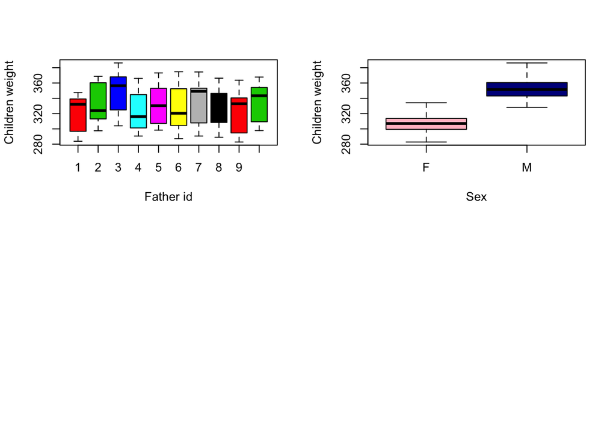

```r
par(mfrow=c(2,2))
## Plot shows that there are differences in weight for different father id and sex.
plot(factor(sort_consistency$faid),sort_consistency$weight,col=2:11,
     xlab = c("Father id"), ylab=c('Children weight'))
plot(sort_consistency$sex, sort_consistency$weight,col=c("pink", "blue4"),
     ylab=c('Children weight'), xlab=c('Sex'))
```

### 4.2 Investigate more by fitting a linear regresion

Fit M1-M5 with faid and sex, based on the p-vlaues for each variable, M5 is genetic markers that are associated with weight-adjusted for faid and sex. In addition, from the results of the summary(fitM5), the M1 allele in M5 marker increases weight, so it is appropriate to make a dummy variable for ensuring this. Based on fitM5M1, holding other variables constant, the M1 in the M5 marker increases weight by 15.7683 lbs on average.

```r
fitM5 <- lm(weight ~ factor(faid) + factor( sex)+ M5, data = sort_consistency)
summary(fitM5)
```

```
##
## Call:
## lm(formula = weight ~ factor(faid) + factor(sex) + M5, data = sort_consistency)
##
## Residuals:
##      Min       1Q   Median       3Q      Max
## -14.1965  -3.1614  -0.1088   3.4640  13.5452
##
## Coefficients:
##                Estimate Std. Error t value Pr(>|t|)
## (Intercept)    305.8941     1.8210 167.978  < 2e-16 ***
## factor(faid)2   10.5612     1.3077   8.076 9.71e-15 ***
## factor(faid)3   18.0199     1.2845  14.029  < 2e-16 ***
## factor(faid)4    6.1356     1.2108   5.067 6.40e-07 ***
## factor(faid)5   13.2869     1.1961  11.109  < 2e-16 ***
## factor(faid)6    9.5285     1.2920   7.375 1.10e-12 ***
## factor(faid)7   12.9620     1.2008  10.794  < 2e-16 ***
## factor(faid)8    5.5786     1.3428   4.154 4.06e-05 ***
## factor(faid)9    1.2771     1.1975   1.067   0.2869
## factor(faid)10  14.7985     1.1901  12.435  < 2e-16 ***
## factor(sex)M    46.1443     0.5205  88.651  < 2e-16 ***
## M5M1 _ M2        1.5030     1.8059   0.832   0.4058
## M5M1 _ M3        2.3292     1.7011   1.369   0.1718
## M5M1 _ M4        3.4039     1.7964   1.895   0.0589 .
## M5M1 _ M5        1.9283     1.9255   1.001   0.3173
## M5M1 _ M6        2.2322     1.8541   1.204   0.2294
## M5M2 _ M2      -16.2764     2.1256  -7.657 1.70e-13 ***
## M5M2 _ M3      -14.6020     1.7303  -8.439 7.50e-16 ***
## M5M2 _ M4      -14.0301     1.8019  -7.786 7.13e-14 ***
## M5M2 _ M5      -14.3069     1.9398  -7.376 1.10e-12 ***
## M5M2 _ M6      -17.0073     2.0941  -8.122 7.07e-15 ***
## M5M3 _ M3      -14.1433     1.8719  -7.556 3.36e-13 ***
## M5M3 _ M4      -13.5762     1.6877  -8.044 1.21e-14 ***
## M5M3 _ M5      -12.4155     1.8461  -6.725 6.74e-11 ***
## M5M3 _ M6      -14.0561     1.7902  -7.852 4.56e-14 ***
## M5M4 _ M4       -9.4506     2.0329  -4.649 4.66e-06 ***
## M5M4 _ M5      -12.3568     1.9976  -6.186 1.65e-09 ***
## M5M4 _ M6      -10.0311     2.3964  -4.186 3.56e-05 ***
## ---
## Signif. codes:  0 '***' 0.001 '**' 0.01 '*' 0.05 '.' 0.1 ' ' 1
##
## Residual standard error: 5.052 on 367 degrees of freedom
## Multiple R-squared:  0.9628, Adjusted R-squared:   0.96
## F-statistic: 351.4 on 27 and 367 DF,  p-value: < 2.2e-16
```

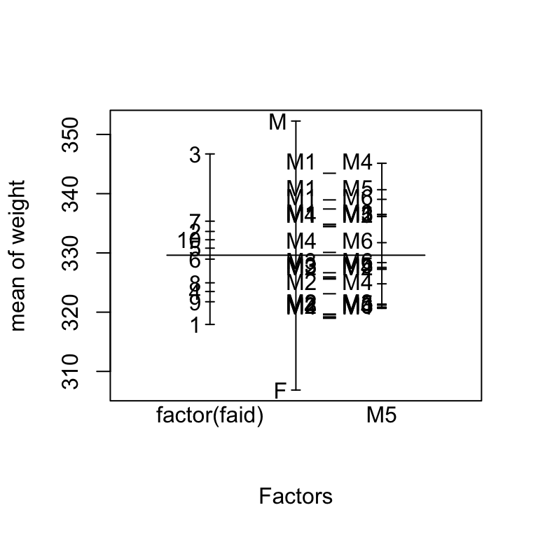

```r
plot.design(weight ~  factor(faid) +factor(sex)+ M5, data=sort_consistency, col="black")
```

```r
iM1 <- grep("M1", sort_consistency$M5)
M5M1<-rep(0, length=nrow(sort_consistency))
M5M1[iM1] <- 1

fitM5M1 <- lm(weight ~ factor(faid) +factor(sex)+M5M1, data=sort_consistency)
summary(fitM5M1)
```

```
##
## Call:
## lm(formula = weight ~ factor(faid) + factor(sex) + M5M1, data = sort_consistency)
##
## Residuals:
##      Min       1Q   Median       3Q      Max
## -15.1228  -3.2313  -0.1528   3.4768  13.6278
##
## Coefficients:
##                Estimate Std. Error t value Pr(>|t|)
## (Intercept)    292.1877     0.8919 327.585  < 2e-16 ***
## factor(faid)2   10.4844     1.2328   8.504 4.15e-16 ***
## factor(faid)3   18.8444     1.2328  15.286  < 2e-16 ***
## factor(faid)4    7.0603     1.1744   6.012 4.28e-09 ***
## factor(faid)5   12.8356     1.1751  10.923  < 2e-16 ***
## factor(faid)6    9.7079     1.2037   8.065 9.47e-15 ***
## factor(faid)7   13.5751     1.1737  11.566  < 2e-16 ***
## factor(faid)8    5.2517     1.2343   4.255 2.63e-05 ***
## factor(faid)9    0.7017     1.1775   0.596    0.552
## factor(faid)10  14.2905     1.1728  12.185  < 2e-16 ***
## factor(sex)M    46.0398     0.5220  88.191  < 2e-16 ***
## M5M1            15.7683     0.6367  24.765  < 2e-16 ***
## ---
## Signif. codes:  0 '***' 0.001 '**' 0.01 '*' 0.05 '.' 0.1 ' ' 1
##
## Residual standard error: 5.14 on 383 degrees of freedom
## Multiple R-squared:  0.9598, Adjusted R-squared:  0.9586
## F-statistic: 830.4 on 11 and 383 DF,  p-value: < 2.2e-16
```